# An Overview of the Data Science Workflow using R

[figure not shown]

# Talk Overview

1. Introduction
2. Overview of RStudio and R notebooks
3. View functionality of Chicago crimes Shiny app
4. Discussion of `tidyverse`, `ggplot2` and other libraries usage within source code of app
5. Review how Shiny apps work
6. Questions

# Introduction to R Notebooks

This is an R Notebook. It is an upgrade to R Markdown for the following reasons:

- It is interactive and can be knit to html.
- Single code chunks can be ran one at a time, as well as in line code such as 2 + 2 = 4.
- Results are shown without having to re-knit the entire document.
- Languages other than R can be used.

```python
def fib(n):
  a, b = 0, 1
  for _ in xrange(n):
    yield a
    a, b = b, a + b
print list(fib(11))
```

```
[0, 1, 1, 2, 3, 5, 8, 13, 21, 34, 55]
```

# Workflow Overview

## Load libraries, source functions

Loading the `tidyverse` library loads the following packages:

- ggplot2
- dplyr
- tidyr
- readr
- purrr
- tibble

```r
library(tidyverse)
library(lubridate)
library(stringr)
source("chicago_crime/source_functions.R")
```

## Read and prepare data

The `readr` library can be useful for reading a variety of file formats and can be much faster than base R data reading functions.

```r
crime_dat_raw <- readr::read_csv("chicago_crime.csv")
crime_dat <- edit_raw_data(raw_data = crime_dat_raw)

saveRDS(crime_dat, "chicago_crime/crime_dat_2016.RDS")
```

```r
crime_dat <- readRDS("chicago_crime/crime_dat_2016.RDS")
```

## Manipulating data

### dplyr

#### Pipe operator: `%>%`

The pipe operator (originally part of the `magrittr` library) makes for very readable, smart code.

The pipe operator works by taking an object and piping it to the first argument of the next function.

##### Poem Example

Below is an example from Hadley Wickham’s example of the enhanced readability of code when using the pipe operator over standard base R functionality.

> Little bunny Foo Foo Hopping through the forest Scooping up the field mice And bopping them on the head

Using base R functionality:

```r
foo_foo <- little_bunny()
bop_on(scoop_up(hop_through(foo_foo, forest), field_mouse), head)
```

Using tidyverse functionality:

```r
foo_foo %>%
  hop_through(forest) %>%
  scoop_up(field_mouse) %>%
  bop_on(head)
```

#### Non-standard evaluation

Non-standard evaluation is a unique syntactical feature within R that allows the program to use the name of an object in addition to its value.

Non-standard evaluation is used for three common purposes:

1. Labelling – uses the expressions rather than the values as labels
2. Non-standard scoping – looks for objects in a data frame or list before looking in the global environment
3. Metaprogramming – computing on unevaluated code

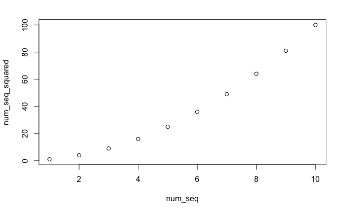

```r
num_seq <- 1:10
num_seq_squared <- num_seq^2
plot(num_seq, num_seq_squared)
```

## Visualizing data

### ggplot2

The `ggplot2` library is based on the “grammar of graphics”, a system of generating graphs based on a few simple components:

- a single or multiple data sets
- geometries (geom) which are visual representations of data points with corresponding aesthetics (aes) such as x, y, size, color
- a coordinate system

Aesthetics are mapped from the data frame to the geom layer to create a simple plot that can be customized (scale, colors, window, theme, etc.) with additional elements.

#### Plot data preparation

```r
crime_burg <- filter_crime_data(crime_dat = crime_dat,
                                     start = "2016-01-01",
                                     end = "2016-03-01",
                                     crime = "Burglary",
                                     group = "Description")
barplot_data_list <- create_barplot_data(crime_filter = crime_burg,
                                    time_measure = "hour",
                                    north = 41.96766,
                                    east = -87.37907,
                                    south = 41.78872,
                                    west = -87.88033)
```

Barplot using `ggplot2`:

```r
head(barplot_data_list$long_data)
```

| time_unit | Group_plot | n |
| --- | --- | --- |
| 0 | Home Invasion | 2 |
| 0 | Attempt Forcible Entry | 3 |
| 0 | Unlawful Entry | 10 |
| 0 | Forcible Entry | 18 |
| 1 | Home Invasion | 1 |
| 1 | Attempt Forcible Entry | 4 |

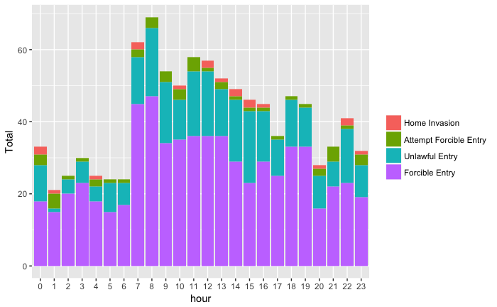

```r
plot_barplot_by_time_loc(barplot_data_list)
```

Using base R plotting functionality:

```r
head(barplot_data_list$table_data)
```

```
    Home Invasion Attempt Forcible Entry Unlawful Entry Forcible Entry
  0             2                      3             10             18
  1             1                      4              1             15
  2             0                      1              4             20
  3             0                      1              6             23
  4             1                      2              4             18
  5             0                      1              8             15
```

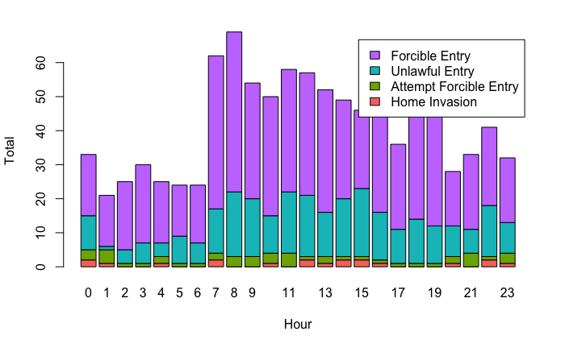

```r
barplot(height = t(barplot_data_list$table_data),
        col = barplot_data_list$colors,
        xlab = "Hour", ylab = "Total",
        legend = colnames(barplot_data_list$table_data))
```

Another example of ggplot vs base R:

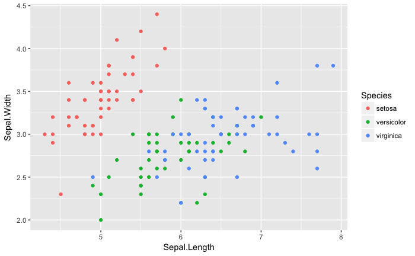

```r
ggplot(iris, aes(x = Sepal.Length, y = Sepal.Width, col = Species)) +
  geom_point()
```

In base R:

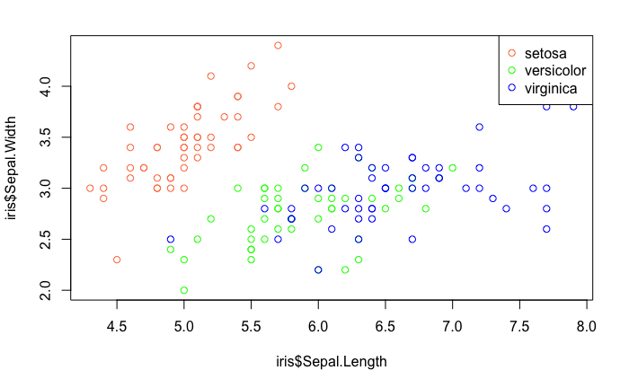

```r
iris$color <- ifelse(iris$Species=="setosa", "coral",
                     ifelse(iris$Species=="versicolor", "green",
                            "blue"))
plot(iris$Sepal.Length, iris$Sepal.Width, col = iris$color)
legend("topright",legend = c("setosa", "versicolor", "virginica"),
        col = c("coral", "green", "blue"), pch = 21)
```

## Interactive Shiny app

Shiny is a library developed by RStudio to create easy, interactive web applications without the use of JavaScript.

A basic shiny app consists of:

- A UI object
- A server function

```r
options(shiny.reactlog = TRUE)
shiny::showReactLog()
```

# Find all files on GitHub

https://github.com/jmaddalena/R_workflow_talk

# References

https://catalog.data.gov/dataset/crimes-2001-to-present-398a4

http://adv-r.had.co.nz/Computing-on-the-language.html

https://shiny.rstudio.com/articles/reactivity-overview.html

https://shiny.rstudio.com/reference/shiny/latest/showReactLog.html

http://docs.rstudio.com/shinyapps.io/getting-started.html